# A quick demo for eddie

X Shen 18 May, 2022

```r
library(knitr)
```

# Eddie

## Local set up

- [Register](https://www.ed.ac.uk/information-services/computing/desktop-personal/vpn/vpn-service-registration) your VPN service
- Connect to VPN using [FortiClinet](https://www.ed.ac.uk/information-services/computing/desktop-personal/vpn/forticlient-vpn)
- Download and set up [MobaXterm](https://mobaxterm.mobatek.net/download.html)

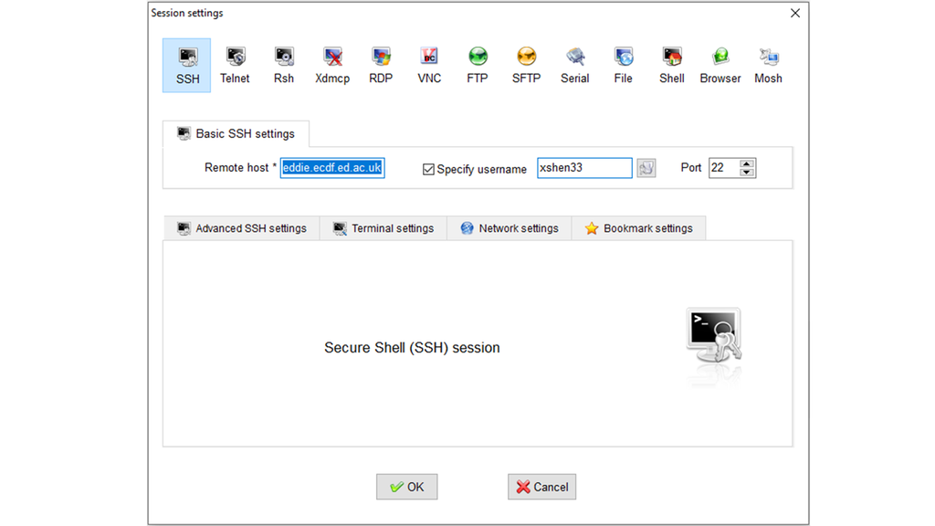

- Download and set up WinSCP

[figure not shown]

## Two ways of using Eddie

- Log on an interactive node

```bash
qlogin -l h_vmem=8G
```

You can specify how much memory is needed by specifying the ‘h_vmem’ option. The larger the dataset you work with and the more complex your analysis is, the larger momery is needed. It is difficult to know precisely how much memory is needed before running a script, even if you are very familiar with Eddie. It requires a bit of trail and error.

To quit an interactive session, type ‘**exit**’ in the terminal

- Submit a code job to Eddie

Find an example script [here](https://github.com/xshen796/CodingClubPsych/blob/master/Eddie_demo/Eddie_job) or copy and paste the script below in an empty plain text file you created:

```bash
#!/bin/sh
#$ -N eddie_demo
#$ -cwd
#$ -m beas
#$ -M s1517658@ed.ac.uk
#$ -l h_vmem=32G
#$ -pe sharedmem 2
#$ -l h_rt=24:00:00
. /etc/profile.d/modules.sh
source ~/.bash_profile

module load igmm/apps/R/4.1.0

echo 'You are a genius' >> test.txt
```

If you submit a code job to Eddie, the job will run without your immediate monitor. It will start running as long as a node that meets your requirements is available. This is particularly helpful if you require a large node for your job.

- Monitor a job submitted to Eddie

```bash
qstat
```

States: **‘r’ = running; ‘qw’ = queue waiting**; ‘hqw’ = hold queue waiting

## Other references about Eddie

- A complete guide for Eddie can be found [here](https://www.wiki.ed.ac.uk/pages/viewpage.action?spaceKey=ResearchServices&title=Eddie)

## Working directories that are available to you

- Group space (which you will create): /exports/igmm/eddie/GenScotDepression/
- Home space: /home/
- Personal scratch space: /exports/eddie/scratch/

## Share your files with others

By default, files you created will be accessible only to you. Before sharing it with others, you will need to specify the rights of the files to make it read-able to others. To do this (for an example file test_file.txt), use the example script as below:

```bash
# Add read permission
chmod +r test_file.txt
# Add write permission
chmod +w test_file.txt
# Add execute permission
chmod +x test_file.txt

# Usually, if you'd like to share a file, it's useful to add both read and execute permission to the file

chmod +rx test_file.txt
```

## Use R on Eddie

- Load R into Eddie

  ```bash
  module load igmm/apps/R/4.1.0
  ```

- Open an R terminal

  ```bash
  R
  ```

- Quit R

  ```bash
  quit()
  #Save workspace image? [y/n/c]: n
  ```

# Methylation data for Generation Scotland

## Access data on Eddie

### Access data on High Performance Computing (HPC) cluster

/exports/igmm/eddie/GenScotDepression/data/genscot/

In this folder, subfolders contain methylation data (methylation), phenotypes (phenotypes) and genetic data (genotypes/GS20K_PLINK_files/).

### Access data in datastore (this is where most of the data is safely stored)

You’ll need to log on a ‘staging node’ to access datastore, in a way that is similar with logging on an interactive node. Use the script below:

```bash
qlogin -q staging

cd /exports/igmm/datastore/GenScotDepression/data
```

Usually, after finding the data you need, you’ll copy the data over to your scratch space for further analysis.